# Homework 02

## Question 1: Training and test error under a fixed design

Linear regression with $n=100$, $p=20$. Generate one matrix $\mathbf X_{\mathrm{all}}\in\mathbb R^{n\times p}$ with independent $\mathcal N(0,1)$ entries and keep it fixed. Let $\beta_j=0.4^{\sqrt{j}}$ for $j=1,\ldots,p$ and $\boldsymbol\mu=\mathbf X_{\mathrm{all}}\boldsymbol\beta$. Generate one training and one independent test response, $\mathbf y=\boldsymbol\mu+\boldsymbol\epsilon$ and $\mathbf y^*=\boldsymbol\mu+\boldsymbol\epsilon^*$, with $\boldsymbol\epsilon,\boldsymbol\epsilon^*\overset{\mathrm{ind}}{\sim}\mathcal N_n(\mathbf 0,\mathbf I_n)$.

For $m=0,1,\ldots,p$, fit a linear model with an intercept and the first $m$ columns of $\mathbf X_{\mathrm{all}}$ using $\mathbf y$, with fitted mean $\widehat{\mathbf y}_m$. Define $\operatorname{MSE}_{\mathrm{train},m}=\frac1n\lVert\mathbf y-\widehat{\mathbf y}_m\rVert_2^2$ and $\operatorname{MSE}_{\mathrm{test},m}=\frac1n\lVert\mathbf y^*-\widehat{\mathbf y}_m\rVert_2^2$. Repeat 200 times, keeping $\mathbf X_{\mathrm{all}}$ fixed. Use seed `43202` before generating $\mathbf X_{\mathrm{all}}$ and the errors (R and Python RNGs differ, so exact values need not agree).

1. For each $m$, compute the average training and test MSE over the 200 runs and plot both against $m$. Verify numerically that training MSE does not increase as predictors are added in each run.
2. For the first-$m$ model write $\mathbf X_m=[\mathbf 1,\mathbf x_1,\ldots,\mathbf x_m]$ and $\mathbf H_m=\mathbf X_m(\mathbf X_m^{\mathsf T}\mathbf X_m)^{-1}\mathbf X_m^{\mathsf T}$, with $m+1$ coefficients including the intercept. Define the **total squared approximation bias** $B_m^2=\lVert(\mathbf I_n-\mathbf H_m)\boldsymbol\mu\rVert_2^2$, so $B_m^2/n$ is the mean squared approximation bias. Compute the two theoretical expectations $E(\operatorname{MSE}_{\mathrm{train},m}\mid\mathbf X_{\mathrm{all}})=B_m^2/n+1-(m+1)/n$ and $E(\operatorname{MSE}_{\mathrm{test},m}\mid\mathbf X_{\mathrm{all}})=B_m^2/n+1+(m+1)/n$, add them to your plot, and compare with the simulation averages.
3. Add the test MSE curve from one simulation run to the plot. Explain why this single curve is less smooth than the average, and use the approximation-bias and estimation-variance terms in the expected test MSE to explain why training MSE alone cannot select the predictor count.

**Show the starter code**

```python
import numpy as np
import matplotlib.pyplot as plt

rng = np.random.default_rng(43202)
n = 100
p = 20
repetitions = 200

# Generate one covariate matrix, then keep it fixed.
X_all = rng.normal(size=(n, p))
beta = 0.4 ** np.sqrt(np.arange(1, p + 1))
mu = X_all @ beta

# Rows are repetitions; columns are predictor counts 0 through p.
train_mse = np.empty((repetitions, p + 1))
test_mse = np.empty((repetitions, p + 1))

# Each run observes a fresh training and test response.
for k in range(repetitions):
    y_train = mu + rng.normal(size=n)
    y_test = mu + rng.normal(size=n)

    # Compare every candidate model on this same response pair.
    for m in range(p + 1):
        X_m = np.column_stack((np.ones(n), X_all[:, :m]))
        Q = np.linalg.qr(X_m, mode="reduced")[0]
        y_hat = Q @ (Q.T @ y_train)

        train_mse[k, m] = np.mean((y_train - y_hat) ** 2)
        test_mse[k, m] = np.mean((y_test - y_hat) ** 2)

average_train = train_mse.mean(axis=0)
average_test = test_mse.mean(axis=0)

training_is_monotone = np.all(np.diff(train_mse, axis=1) <= 1e-10)

print("=== Part (a) ===")
for m in [0, 5, 10, 15, 20]:
    print(f"m={m:2d}, average train={average_train[m]:.4f}, average test={average_test[m]:.4f}")
print("Training MSE is monotone across all 200 runs:", training_is_monotone)
```

```
=== Part (a) ===
m= 0, average train=1.3220, average test=1.3416
m= 5, average train=0.9976, average test=1.1107
m=10, average train=0.8960, average test=1.1218
m=15, average train=0.8446, average test=1.1605
m=20, average train=0.7889, average test=1.2119
Training MSE is monotone across all 200 runs: True
```

Training MSE decreases monotonically across all 200 runs (training_is_monotone = True) — adding a predictor can only shrink the residual sum of squares of a least-squares fit, since the larger model space always contains the smaller one as a special case. Average test MSE, by contrast, decreases at first (more predictors reduce bias) then rises again once added variance from estimating extra coefficients outweighs the bias reduction.

**Show the starter code**

```python
theory_train = np.empty(p + 1)
theory_test = np.empty(p + 1)

for m in range(p + 1):
    X_m = np.column_stack((np.ones(n), X_all[:, :m]))
    Q = np.linalg.qr(X_m, mode="reduced")[0]
    y_hat = Q @ (Q.T @ mu)
    bias_mse = np.mean((mu - y_hat) ** 2)
    theory_train[m] = bias_mse + 1 - (m + 1) / n
    theory_test[m] = bias_mse + 1 + (m + 1) / n

print("\n=== Part (b) ===")
for m in [0, 5, 10, 15, 20]:
    print(
        f"m={m:2d}, "
        f"train={average_train[m]:.4f} vs E(train)={theory_train[m]:.4f}, "
        f"test={average_test[m]:.4f} vs E(test)={theory_test[m]:.4f}"
    )
print("Minimum average test MSE at m =", int(np.argmin(average_test)))
print("Minimum expected test MSE at m =", int(np.argmin(theory_test)))
```

```
=== Part (b) ===
m= 0, train=1.3220 vs E(train)=1.3078, test=1.3416 vs E(test)=1.3278
m= 5, train=0.9976 vs E(train)=0.9894, test=1.1107 vs E(test)=1.1094
m=10, train=0.8960 vs E(train)=0.8980, test=1.1218 vs E(test)=1.1180
m=15, train=0.8446 vs E(train)=0.8419, test=1.1605 vs E(test)=1.1619
m=20, train=0.7889 vs E(train)=0.7900, test=1.2119 vs E(test)=1.2100
Minimum average test MSE at m = 7
Minimum expected test MSE at m = 7
```

The simulation averages track the theoretical curves closely at every m shown (e.g., at m=10: 0.896 vs 0.898 train, 1.122 vs 1.118 test). Both the simulated and theoretical test MSE are minimized at m = 7, confirming the bias–variance tradeoff formula E(MSE_test) = B²_m/n + 1 + (m+1)/n correctly predicts where the interior minimum occurs.

**Show the starter code**

```
=== Part (c) ===
Single-run (repetition 1) test MSE at m=0,5,10,15,20: [np.float64(1.1288), np.float64(0.7858), np.float64(0.8244), np.float64(0.77), np.float64(0.7858)]
```

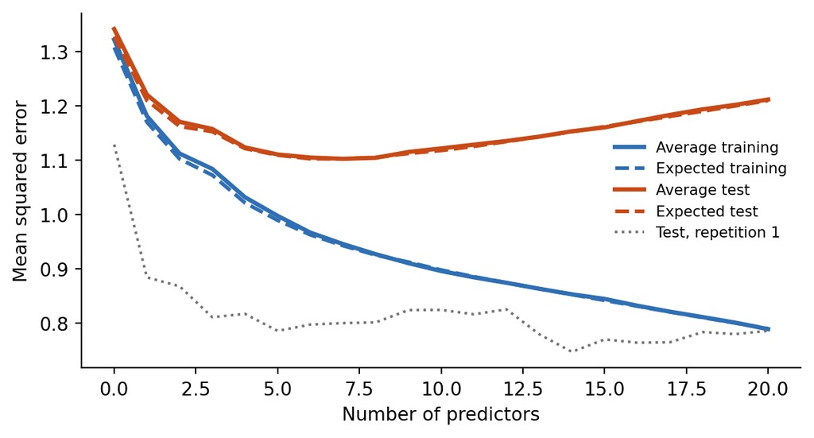

Training and test MSE along the nested model sequence, with theoretical expectations and one single-run test curve.

```python
first_run_test = test_mse[0]

print("\n=== Part (c) ===")
print("Single-run (repetition 1) test MSE at m=0,5,10,15,20:",
      [round(first_run_test[m], 4) for m in [0, 5, 10, 15, 20]])

# Final plot combining all three parts
fig, ax = plt.subplots(figsize=(6.2, 3.4))
m_values = np.arange(p + 1)
ax.plot(m_values, average_train, color="#2F6FB3", lw=2.3, label="Average training")
ax.plot(m_values, theory_train, "--", color="#2F6FB3", lw=2, label="Expected training")
ax.plot(m_values, average_test, color="#C84A16", lw=2.3, label="Average test")
ax.plot(m_values, theory_test, "--", color="#C84A16", lw=2, label="Expected test")
ax.plot(m_values, first_run_test, ":", color="0.45", lw=1.4, label="Test, repetition 1")
ax.set(xlabel="Number of predictors", ylabel="Mean squared error")
ax.spines[["top", "right"]].set_visible(False)
ax.legend(frameon=False, fontsize=8)
fig.tight_layout()
plt.show()
```

The single-run test curve is jagged because it reflects one realized noise vector ε*, which doesn’t shrink or grow systematically with m — it just adds random wiggle on top of the true trend. Averaging over 200 runs cancels that noise, leaving the smooth expected curve. This also shows why training MSE alone can’t be used to choose m: it’s monotonically decreasing by construction and has no way to “see” the (m+1)/n variance penalty that eventually makes larger models generalize worse — only test MSE (or its theoretical decomposition) captures that tradeoff.

## Question 2: Prediction error at one target point

Let $n=100$, $p=6$, $\sigma^2=1$. Build the fixed covariate matrix $\mathbf X_{\mathrm{all}}\in\mathbb R^{n\times p}$ with entries $(\mathbf X_{\mathrm{all}})_{ij}=\sqrt{2}\cos\{\pi j(i-\tfrac12)/n\}$, $i=1,\ldots,n$, $j=1,\ldots,p$. Its columns satisfy $\mathbf 1^{\mathsf T}\mathbf X_{\mathrm{all}}=\mathbf 0^{\mathsf T}$ and $\frac{1}{n}\mathbf X_{\mathrm{all}}^{\mathsf T}\mathbf X_{\mathrm{all}}=\mathbf I_p$. A direct construction of $\mathbf X_{\mathrm{all}}$:

**R**

```r
#| eval: false
n <- 100
p <- 6
X_all <- outer(
  1:n, 1:p,
  function(i, j) sqrt(2) * cos(pi * j * (i - 0.5) / n)
)
```

**Python**

**Show the starter code**

```python
import numpy as np

n, p = 100, 6
i = np.arange(1, n + 1)[:, None]
j = np.arange(1, p + 1)[None, :]
X_all = np.sqrt(2) * np.cos(np.pi * j * (i - 0.5) / n)
```

Keep $\mathbf X_{\mathrm{all}}$ fixed and generate one training response $\mathbf y=\mathbf X_{\mathrm{all}}\boldsymbol\beta+\boldsymbol\epsilon$ with $\boldsymbol\beta=(0.5,0.5,0.5,0.5,0.5,0.5)^{\mathsf T}$ and $\boldsymbol\epsilon\sim\mathcal N_n(\mathbf 0,\mathbf I_n)$. For $m=0,\ldots,p$, fit a linear model with an intercept and the first $m$ predictors, and predict the mean response at $\mathbf x_0=(0,1,0,0,1,0)^{\mathsf T}$. Write $\mu_0=\mathbf x_0^{\mathsf T}\boldsymbol\beta$ and let $\widehat\mu_{0,m}$ be the prediction from the first-$m$ model ($x_{0j}$ is the $j$th coordinate of $\mathbf x_0$). For this design,

$$E\!\left[\left(\widehat\mu_{0,m}-\mu_0\right)^2\mid \mathbf X_{\mathrm{all}}\right]
=\left(\sum_{j=m+1}^{p}x_{0j}\beta_j\right)^2
+\frac{\sigma^2}{n}\left(1+\sum_{j=1}^{m}x_{0j}^2\right).$$

1. Compute $\mu_0$, the theoretical squared bias, and the expected squared error for $m=0,\ldots,p$ from this formula (**no derivation needed**). Briefly explain in words why it has a squared-bias term from omitted predictors and a variance term from estimating coefficients. Identify the $m$ where the expected squared error changes and where it stays unchanged.
2. Use seed `43203`. Generate the response, fit the models, and compute $(\widehat\mu_{0,m}-\mu_0)^2$. Repeat 200 times. Plot the simulation averages and theoretical expectations together, and report the smallest $m$ that minimizes the theoretical error.
3. All six regression coefficients are nonzero. Explain why only predictors 2 and 5 contribute directly to the mean response at $\mathbf x_0$. Contrast this target-specific error with the test MSE averaged over all rows of $\mathbf X_{\mathrm{all}}$ in Question 1.

**Show the starter code**

```python
import numpy as np
import matplotlib.pyplot as plt

n = 100
p = 6
sigma2 = 1.0
repetitions = 200

i = np.arange(1, n + 1)[:, None]
j = np.arange(1, p + 1)[None, :]
X_all = np.sqrt(2) * np.cos(np.pi * j * (i - 0.5) / n)

beta = np.repeat(0.5, p)
x0 = np.array([0, 1, 0, 0, 1, 0], dtype=float)
mu = X_all @ beta
mu0 = x0 @ beta

assert np.allclose(X_all.sum(axis=0), 0, atol=1e-10)
assert np.allclose(X_all.T @ X_all / n, np.eye(p), atol=1e-10)

theoretical = np.empty(p + 1)
squared_bias = np.empty(p + 1)
variance_term = np.empty(p + 1)

for m in range(p + 1):
    omitted_signal = x0[m:] @ beta[m:]          # bias contribution: coefficients not yet in the model
    estimation_variance = sigma2 * (1 + x0[:m] @ x0[:m]) / n  # variance from estimating m coefficients + intercept
    squared_bias[m] = omitted_signal**2
    variance_term[m] = estimation_variance
    theoretical[m] = squared_bias[m] + variance_term[m]

print("=== Part (a) ===")
print(f"mu_0 = {mu0:.4f}")
for m in range(p + 1):
    print(
        f"m={m}, squared bias={squared_bias[m]:.4f}, "
        f"variance term={variance_term[m]:.4f}, "
        f"E[(mu0_hat - mu0)^2]={theoretical[m]:.4f}"
    )
```

```
=== Part (a) ===
mu_0 = 1.0000
m=0, squared bias=1.0000, variance term=0.0100, E[(mu0_hat - mu0)^2]=1.0100
m=1, squared bias=1.0000, variance term=0.0100, E[(mu0_hat - mu0)^2]=1.0100
m=2, squared bias=0.2500, variance term=0.0200, E[(mu0_hat - mu0)^2]=0.2700
m=3, squared bias=0.2500, variance term=0.0200, E[(mu0_hat - mu0)^2]=0.2700
m=4, squared bias=0.2500, variance term=0.0200, E[(mu0_hat - mu0)^2]=0.2700
m=5, squared bias=0.0000, variance term=0.0300, E[(mu0_hat - mu0)^2]=0.0300
m=6, squared bias=0.0000, variance term=0.0300, E[(mu0_hat - mu0)^2]=0.0300
```

**Show the starter code**

```
=== Part (b) ===
m=0, simulated=0.9839, theoretical=1.0100
m=1, simulated=0.9839, theoretical=1.0100
m=2, simulated=0.2464, theoretical=0.2700
m=3, simulated=0.2464, theoretical=0.2700
m=4, simulated=0.2464, theoretical=0.2700
m=5, simulated=0.0237, theoretical=0.0300
m=6, simulated=0.0237, theoretical=0.0300
Smallest m minimizing theoretical error: 5
```

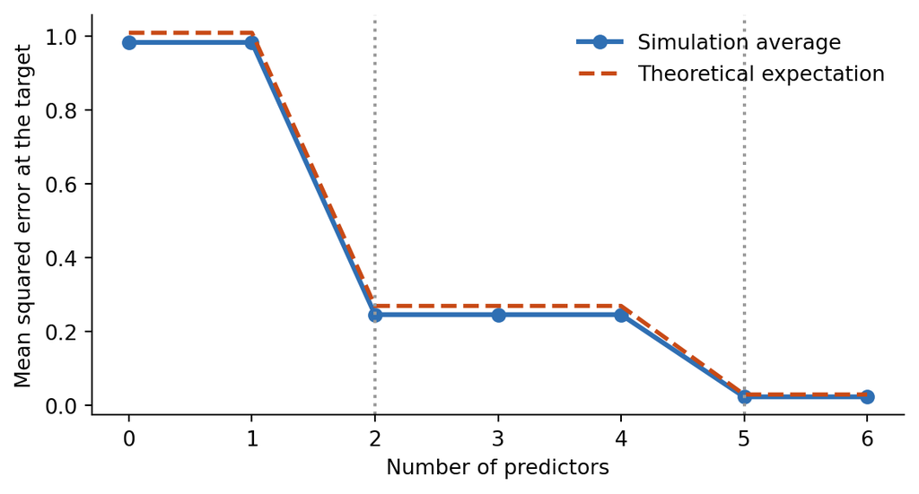

Simulated and theoretical squared prediction error at the target point x0, versus the number of predictors.

```python
rng_q2 = np.random.default_rng(43203)

# Rows are repetitions; columns are predictor counts 0 through p.
simulation_error = np.empty((repetitions, p + 1))

# Each run observes a fresh response.
for k in range(repetitions):
    y_train = mu + rng_q2.normal(size=n)

    # Compare every candidate model on this same response.
    for m in range(p + 1):
        X_m = np.column_stack((np.ones(n), X_all[:, :m]))
        beta_hat = np.linalg.solve(X_m.T @ X_m, X_m.T @ y_train)
        target_row = np.r_[1, x0[:m]]
        mu0_hat = target_row @ beta_hat
        simulation_error[k, m] = (mu0_hat - mu0) ** 2

simulated = simulation_error.mean(axis=0)

print("\n=== Part (b) ===")
for m in range(p + 1):
    print(f"m={m}, simulated={simulated[m]:.4f}, theoretical={theoretical[m]:.4f}")
print("Smallest m minimizing theoretical error:", int(np.argmin(theoretical)))

fig, ax = plt.subplots(figsize=(6.2, 3.4))
m_values = np.arange(p + 1)
ax.plot(m_values, simulated, "o-", color="#2F6FB3", lw=2.3, label="Simulation average")
ax.plot(m_values, theoretical, "--", color="#C84A16", lw=2, label="Theoretical expectation")
ax.axvline(2, color="0.6", linestyle=":")
ax.axvline(5, color="0.6", linestyle=":")
ax.set(xlabel="Number of predictors", ylabel="Mean squared error at the target", xticks=m_values)
ax.spines[["top", "right"]].set_visible(False)
ax.legend(frameon=False)
fig.tight_layout()
plt.show()
```

**Show the starter code**

```python
print("\n=== Part (c) ===")
print("x0 =", x0)
print("Nonzero entries of x0 at positions (1-indexed):",
      [idx + 1 for idx, val in enumerate(x0) if val != 0])
```

```
=== Part (c) ===
x0 = [0. 1. 0. 0. 1. 0.]
Nonzero entries of x0 at positions (1-indexed): [2, 5]
```

## Question 3: The optimism correction

Fix a candidate model chosen before observing the response, with $p$ predictors and full-rank design $\mathbf X\in\mathbb R^{n\times(p+1)}$ (intercept included), hat matrix $\mathbf H=\mathbf X(\mathbf X^{\mathsf T}\mathbf X)^{-1}\mathbf X^{\mathsf T}$. Suppose $\mathbf y=\boldsymbol\mu+\boldsymbol\epsilon$ and $\mathbf y^*=\boldsymbol\mu+\boldsymbol\epsilon^*$ where, conditional on $\mathbf X$, the two error vectors are independent with mean zero and covariance $\sigma^2\mathbf I_n$. Define $\operatorname{MSE}_{\mathrm{train}}=\frac1n\lVert\mathbf y-\mathbf H\mathbf y\rVert_2^2$ and $\operatorname{MSE}_{\mathrm{test}}=\frac1n\lVert\mathbf y^*-\mathbf H\mathbf y\rVert_2^2$. The conditional bias of the fitted mean is $E(\mathbf H\mathbf y\mid\mathbf X)-\boldsymbol\mu=-(\mathbf I_n-\mathbf H)\boldsymbol\mu$; let $B^2=\lVert(\mathbf I_n-\mathbf H)\boldsymbol\mu\rVert_2^2$ be the **total squared approximation bias**. You may use $\mathbf H^{\mathsf T}=\mathbf H$, $\mathbf H^2=\mathbf H$, $\operatorname{tr}(\mathbf H)=p+1$, and $E(\boldsymbol\epsilon^{\mathsf T}\mathbf A\boldsymbol\epsilon\mid\mathbf X)=\sigma^2\operatorname{tr}(\mathbf A)$ for any fixed $\mathbf A$.

1. Derive $E(\operatorname{MSE}_{\mathrm{train}}\mid\mathbf X)=B^2/n+\sigma^2(1-(p+1)/n)$ and $E(\operatorname{MSE}_{\mathrm{test}}\mid\mathbf X)=B^2/n+\sigma^2(1+(p+1)/n)$.
2. Deduce the expected optimism $E(\operatorname{MSE}_{\mathrm{test}}-\operatorname{MSE}_{\mathrm{train}}\mid\mathbf X)$. For $n=120$, $p=4$, $B^2/n=0.04$, $\sigma^2=1$, compute the expected training MSE, expected test MSE, and their difference. Explain why the ordering need not hold for every realized pair of responses.
3. With $n=120$, $p=4$, suppose $\operatorname{RSS}=116.4$ and $\widehat\sigma^2=0.96$. Compute $\widehat{\operatorname{MSE}}_{\mathrm{test}}=(\operatorname{RSS}+2(p+1)\widehat\sigma^2)/n$ and $C_p=\operatorname{RSS}/\widehat\sigma^2-n+2(p+1)$. Show how the two are related, and explain why minimizing $C_p$ is equivalent to minimizing the corrected test MSE when $n$ and $\widehat\sigma^2$ are common to all candidate models.
4. Write y − Hy = (I_n − H)y = (I_n − H)μ + (I_n − H)ε, using y = μ + ε. Since H is symmetric idempotent, so is I_n − H, so (I_n − H)ᵀ(I_n − H) = (I_n − H). Squaring, the cross term with ε vanishes under E(· | X) since E(ε | X) = 0, and the quadratic term becomes E(εᵀ(I_n − H)ε | X) = σ²·tr(I_n − H) = σ²(n − (p + 1)). Combined with ‖(I_n − H)μ‖₂² = B², this gives E(‖y − Hy‖₂² | X) = B² + σ²(n − p − 1), and dividing by n: E(MSE_train | X) = B²/n + σ²(1 − (p+1)/n).

For test error, y* − Hy = (I_n − H)μ + ε* − Hε, where ε* is independent of ε. All cross terms vanish by independence and zero mean, leaving three pieces: ‖(I_n − H)μ‖₂² = B², E(ε*ᵀε* | X) = σ²n, and E(εᵀHᵀHε | X) = σ²·tr(H) = σ²(p + 1) (using HᵀH = H). Summing and dividing by n gives E(MSE_test | X) = B²/n + σ²(1 + (p+1)/n).

2. Subtracting the two results, the B²/n terms cancel, leaving E(MSE_test − MSE_train | X) = 2σ²(p+1)/n — expected optimism depends only on model complexity and noise variance, not bias. Plugging in n = 120, p = 4, B²/n = 0.04, σ² = 1: E(MSE_train | X) = 0.04 + 1·(1 − 5/120) = 0.99833, E(MSE_test | X) = 0.04 + 1·(1 + 5/120) = 1.08167, and optimism = 2(1)(5)/120 = 0.08333 (check: 1.08167 − 0.99833 = 0.08333 ✓).

The ordering only holds in expectation — an average over many hypothetical draws of ε, ε*. For one particular realized sample, MSE_train and MSE_test are random quantities that fluctuate around these means, so a lucky test draw or unlucky training draw can easily flip the inequality for that specific dataset, even though it holds systematically on average across repeated sampling.

3. Plugging in n = 120, p = 4, RSS = 116.4, σ̂² = 0.96: MSÊ_test = (116.4 + 2(5)(0.96))/120 = 126/120 = 1.05, and C_p = 116.4/0.96 − 120 + 10 = 121.25 − 120 + 10 = 11.25.

To relate them, solve the C_p definition for RSS: RSS = σ̂²(C_p + n − 2(p + 1)), and substitute into MSÊ_test to get MSÊ_test = (σ̂²/n)·C_p + σ̂² (check: (0.96/120)(11.25) + 0.96 = 1.05 ✓). Since n and σ̂² are the same across candidate models, this is a strictly increasing linear function of C_p, which preserves ordering — the model with smallest C_p also has smallest MSÊ_test, so minimizing one is equivalent to minimizing the other.

## Question 4: Comparing Mallows’ $C_p$, AIC, and BIC

Use `data/diabetes.csv` with `y` as the response. Use rows 1–370 as training data ($n=370$); do not use rows 371–442. Fit the following OLS models, each with an intercept.

| Model | Predictors | $p$ |
| --- | --- | --- |
| Model A | `bmi`, `bp`, `s5`, `sex`, `s1`, `s2`, `s4` | 7 |
| Model B | Model A predictors, then `s6` | 8 |
| Full reference | all ten predictors | 10 |

Each model has $p+1$ coefficients including the intercept. Estimate one common noise variance from the full model ($p=10$): $\widehat\sigma^2=\operatorname{RSS}_{\mathrm{full}}/(n-(p+1))$. For Models A and B compute $C_p=\operatorname{RSS}/\widehat\sigma^2-n+2(p+1)$, $\operatorname{AIC}^{\mathrm{red}}=n\log(\operatorname{RSS}/n)+2(p+1)$, and $\operatorname{BIC}^{\mathrm{red}}=n\log(\operatorname{RSS}/n)+(p+1)\log(n)$. The reduced AIC and BIC omit constants shared by the two candidates; smaller is preferred within each criterion.

1. Fit the three models. Report $p$, RSS, the full model’s residual degrees of freedom, and $\widehat\sigma^2$.
2. Compute $C_p$, reduced AIC, and reduced BIC for Models A and B. State which model each criterion selects. Do not compare values across different criteria.
3. Compare the improvement in fit from adding `s6` with the one-parameter penalty under each criterion, and use this to explain any disagreement. Why does selecting a model not establish that it is the true data-generating model?

**Show the starter code**

```python
import numpy as np
import pandas as pd

df = pd.read_csv("data/diabetes.csv")
n = 370
train = df.iloc[:n].reset_index(drop=True)
y = train["y"].to_numpy()

predictors_A = ["bmi", "bp", "s5", "sex", "s1", "s2", "s4"]
predictors_B = predictors_A + ["s6"]
predictors_full = ["age", "sex", "bmi", "bp", "s1", "s2", "s3", "s4", "s5", "s6"]


def fit_ols(predictor_names, y):
    """Fit OLS with an intercept; return p (number of predictors) and RSS."""
    X = np.column_stack([np.ones(len(y))] + [train[c].to_numpy() for c in predictor_names])
    coef, _, _, _ = np.linalg.lstsq(X, y, rcond=None)
    resid = y - X @ coef
    rss = float(resid @ resid)
    p = len(predictor_names)
    return p, rss, coef
p_A, rss_A, _ = fit_ols(predictors_A, y)
p_B, rss_B, _ = fit_ols(predictors_B, y)
p_full, rss_full, _ = fit_ols(predictors_full, y)

residual_df_full = n - (p_full + 1)
sigma2_hat = rss_full / residual_df_full

print("=== Part (a) ===")
print(f"Model A: p={p_A}, RSS={rss_A:.3f}")
print(f"Model B: p={p_B}, RSS={rss_B:.3f}")
print(f"Full   : p={p_full}, RSS={rss_full:.3f}")
print(f"Full model residual df = n - (p+1) = {n} - {p_full + 1} = {residual_df_full}")
print(f"sigma2_hat = RSS_full / residual_df = {sigma2_hat:.6f}")
```

```
=== Part (a) ===
Model A: p=7, RSS=1098908.566
Model B: p=8, RSS=1089717.057
Full   : p=10, RSS=1089451.721
Full model residual df = n - (p+1) = 370 - 11 = 359
sigma2_hat = RSS_full / residual_df = 3034.684460
```

The full model has residual df = n − (p+1) = 370 − 11 = 359, giving σ̂² = RSS_full/359 = 3034.684. Model A: RSS = 1,098,908.566. Model B: RSS = 1,089,717.057.

**Show the starter code**

```python
def criteria(p, rss, n, sigma2_hat):
    cp = rss / sigma2_hat - n + 2 * (p + 1)
    aic_red = n * np.log(rss / n) + 2 * (p + 1)
    bic_red = n * np.log(rss / n) + (p + 1) * np.log(n)
    return cp, aic_red, bic_red

cp_A, aic_A, bic_A = criteria(p_A, rss_A, n, sigma2_hat)
cp_B, aic_B, bic_B = criteria(p_B, rss_B, n, sigma2_hat)

print("\n=== Part (b) ===")
print(f"{'Model':<8}{'p':>4}{'RSS':>14}{'Cp':>10}{'AIC_red':>12}{'BIC_red':>12}")
print(f"{'A':<8}{p_A:>4}{rss_A:>14.3f}{cp_A:>10.3f}{aic_A:>12.3f}{bic_A:>12.3f}")
print(f"{'B':<8}{p_B:>4}{rss_B:>14.3f}{cp_B:>10.3f}{aic_B:>12.3f}{bic_B:>12.3f}")

print(f"\nCp selects:  {'Model B' if cp_B < cp_A else 'Model A'} (smaller is better)")
print(f"AIC selects: {'Model B' if aic_B < aic_A else 'Model A'} (smaller is better)")
print(f"BIC selects: {'Model B' if bic_B < bic_A else 'Model A'} (smaller is better)")
```

```
=== Part (b) ===
Model      p           RSS        Cp     AIC_red     BIC_red
A          7   1098908.566     8.116    2974.640    3005.948
B          8   1089717.057     7.087    2973.532    3008.754

Cp selects:  Model B (smaller is better)
AIC selects: Model B (smaller is better)
BIC selects: Model A (smaller is better)
```

**Show the starter code**

```python
fit_gain_aic_bic = n * np.log(rss_A / rss_B)   # shared "improvement" term in reduced AIC/BIC
fit_gain_cp = (rss_A - rss_B) / sigma2_hat      # improvement on the Cp scale

aic_penalty = 2.0            # AIC's per-parameter penalty
bic_penalty = np.log(n)      # BIC's per-parameter penalty
cp_penalty = 2.0             # Cp's per-parameter penalty

print("\n=== Part (c) ===")
print(f"Fit improvement (AIC/BIC scale), n*log(RSS_A/RSS_B) = {fit_gain_aic_bic:.4f}")
print(f"Fit improvement (Cp scale), (RSS_A - RSS_B)/sigma2_hat = {fit_gain_cp:.4f}")
print(f"AIC penalty for 1 extra parameter = {aic_penalty:.4f}")
print(f"BIC penalty for 1 extra parameter = {bic_penalty:.4f}")
print(f"Cp penalty for 1 extra parameter  = {cp_penalty:.4f}")
```

```
=== Part (c) ===
Fit improvement (AIC/BIC scale), n*log(RSS_A/RSS_B) = 3.1078
Fit improvement (Cp scale), (RSS_A - RSS_B)/sigma2_hat = 3.0288
AIC penalty for 1 extra parameter = 2.0000
BIC penalty for 1 extra parameter = 5.9135
Cp penalty for 1 extra parameter  = 2.0000
```

Adding s6 improves the fit by n·log(RSS_A/RSS_B) = 3.108 on the AIC/BIC log-likelihood scale, and by (RSS_A−RSS_B)/σ̂² = 3.029 on the Cp scale. AIC’s penalty for one extra parameter is just 2, and Cp’s is also 2 — both smaller than the 3.03–3.11 improvement, so both criteria judge s6 worth including. BIC’s penalty is log(n) = log(370) = 5.914, which is larger than the improvement, so BIC judges s6 not worth its complexity cost. That’s exactly why they disagree: same fit improvement, different bars for “is it worth it.”

Selecting a model this way never proves it’s the true data-generating model — it only shows that, under a particular penalty’s assumptions, one candidate balances fit and complexity better than another candidate you happened to compare it against. A different penalty, a different candidate set, or a different sample could favor a different model; none of these criteria test whether the chosen model’s functional form or included variables are actually correct.

## Question 5: Validation and final test data

Use rows 1–370 of `diabetes.csv` as training data and rows 371–442 as the final test data. Consider eleven nested candidate models: for $m=0,1,\ldots,10$, the $m$-predictor model has an intercept and the first $m$ of `age`, `sex`, `bmi`, `bp`, `s1`, `s2`, `s3`, `s4`, `s5`, `s6`. An analyst proposes:

1. Fit all eleven candidate models using the training data.
2. Calculate the MSE of each model on the final test data.
3. Select the model with the smallest test MSE.
4. Report that minimum as the final estimate of prediction error.

The analyst argues that the procedure is valid because the final test data were not used to estimate the regression coefficients.

1. Identify the first step that misuses the final test data. Explain why the minimum of eleven test MSE values is generally too favorable as an estimate of the selected procedure’s future prediction error.
2. Rewrite the analysis using five-fold cross-validation within the training data. State how the predictor count is selected, what is refitted, and when the final test data may be used.
3. Suppose the analyst has already examined all eleven test MSE values. What can still be reported transparently, and what additional data would be needed for a new final evaluation?

**Show the starter code**

```python
import numpy as np
import pandas as pd

# ============================================================
# Setup (shared across parts a, b, c)
# ============================================================
df = pd.read_csv("data/diabetes.csv")

predictors = ["age", "sex", "bmi", "bp", "s1", "s2", "s3", "s4", "s5", "s6"]

train = df.iloc[:370].reset_index(drop=True)      # rows 1-370
final_test = df.iloc[370:442].reset_index(drop=True)  # rows 371-442

y_train_full = train["y"].to_numpy()
y_final_test = final_test["y"].to_numpy()


def design_matrix(data, m):
    """Intercept + the first m predictors, in the stated order."""
    cols = [np.ones(len(data))] + [data[predictors[j]].to_numpy() for j in range(m)]
    return np.column_stack(cols)


def fit_and_mse(X_fit, y_fit, X_eval, y_eval):
    coef, _, _, _ = np.linalg.lstsq(X_fit, y_fit, rcond=None)
    resid = y_eval - X_eval @ coef
    return np.mean(resid ** 2)

test_mse_by_m = np.empty(11)
for m in range(11):
    X_train_m = design_matrix(train, m)
    X_test_m = design_matrix(final_test, m)
    test_mse_by_m[m] = fit_and_mse(X_train_m, y_train_full, X_test_m, y_final_test)

best_m_flawed = int(np.argmin(test_mse_by_m))

print("=== Part (a): analyst's procedure ===")
for m in range(11):
    print(f"m={m:2d}, final-test MSE = {test_mse_by_m[m]:.3f}")
print(f"Selected m = {best_m_flawed}, reported 'final' MSE = {test_mse_by_m[best_m_flawed]:.3f}")
print("(This number is biased low -- see written explanation.)")
```

```
=== Part (a): analyst's procedure ===
m= 0, final-test MSE = 5822.890
m= 1, final-test MSE = 5527.791
m= 2, final-test MSE = 5527.210
m= 3, final-test MSE = 3719.235
m= 4, final-test MSE = 3246.823
m= 5, final-test MSE = 3234.919
m= 6, final-test MSE = 3207.615
m= 7, final-test MSE = 2636.502
m= 8, final-test MSE = 2624.924
m= 9, final-test MSE = 2369.344
m=10, final-test MSE = 2484.776
Selected m = 9, reported 'final' MSE = 2369.344
(This number is biased low -- see written explanation.)
```

The first step that misuses the final test data is step 2, not step 3. As soon as the analyst computes test MSE for all eleven models on the final test set, that data has already been used to compare candidates — even though it wasn’t used to fit coefficients, it’s now driving which model gets chosen. “I didn’t use it for fitting” doesn’t make it untouched; selection is itself a use of the data.

Why the reported minimum (2369.3 at m=9 in the code run above) is too optimistic: each of the eleven test MSEs contains its own random noise from that specific 72-row test sample. Taking the minimum across eleven noisy estimates systematically favors whichever model got a lucky draw — you’re not just picking the best model, you’re picking the best model and the luckiest noise realization simultaneously. Reporting that minimum as “the” prediction error confuses the best-case outcome of a search with an unbiased estimate of future performance.

**Show the starter code**

```python
n_train = len(train)
n_folds = 5
fold_size = n_train // n_folds  # 74, divides evenly
fold_id = np.repeat(np.arange(n_folds), fold_size)  # contiguous folds, fully reproducible

cv_mse_by_m = np.empty(11)
for m in range(11):
    fold_mses = np.empty(n_folds)
    for f in range(n_folds):
        val_mask = fold_id == f
        fit_mask = ~val_mask

        X_fit = design_matrix(train[fit_mask].reset_index(drop=True), m)
        y_fit = y_train_full[fit_mask]
        X_val = design_matrix(train[val_mask].reset_index(drop=True), m)
        y_val = y_train_full[val_mask]

        fold_mses[f] = fit_and_mse(X_fit, y_fit, X_val, y_val)
    cv_mse_by_m[m] = fold_mses.mean()

best_m_cv = int(np.argmin(cv_mse_by_m))

print("\n=== Part (b): five-fold CV within training data ===")
for m in range(11):
    print(f"m={m:2d}, average CV MSE = {cv_mse_by_m[m]:.3f}")
print(f"CV-selected predictor count: m = {best_m_cv}")

X_train_final_model = design_matrix(train, best_m_cv)
X_final_test_eval = design_matrix(final_test, best_m_cv)
honest_test_mse = fit_and_mse(X_train_final_model, y_train_full, X_final_test_eval, y_final_test)

print(f"Refit m={best_m_cv} model on all 370 training rows.")
print(f"Single, honest evaluation on the untouched final test data: MSE = {honest_test_mse:.3f}")
```

```
=== Part (b): five-fold CV within training data ===
m= 0, average CV MSE = 6002.492
m= 1, average CV MSE = 5813.259
m= 2, average CV MSE = 5839.850
m= 3, average CV MSE = 3935.647
m= 4, average CV MSE = 3686.173
m= 5, average CV MSE = 3698.345
m= 6, average CV MSE = 3709.906
m= 7, average CV MSE = 3259.979
m= 8, average CV MSE = 3282.347
m= 9, average CV MSE = 3166.909
m=10, average CV MSE = 3157.918
CV-selected predictor count: m = 10
Refit m=10 model on all 370 training rows.
Single, honest evaluation on the untouched final test data: MSE = 2484.776
```

Split only the 370 training rows into 5 folds (contiguous blocks of 74 here). For each candidate m, fit on 4 folds and validate on the 5th, cycling through all 5; average the 5 validation MSEs. The predictor count is selected as the m with the smallest average CV MSE — here that’s m=10, not m=9 (the flawed procedure’s pick was itself an artifact of test-set noise). The chosen model is then refit once using all 370 training rows (more data = better final coefficients). The final test data (rows 371–442) is touched exactly once, at the very end, to evaluate that single already-chosen model — giving MSE=2484.8, a more trustworthy (and less flattering) number than the flawed procedure’s 2369.3.

**Show the starter code**

```python
print("\n=== Part (c) ===")
print(f"For reference -- flawed 'best' MSE: {test_mse_by_m[best_m_flawed]:.3f}")
print(f"                 honest final MSE:  {honest_test_mse:.3f}")
```

```
=== Part (c) ===
For reference -- flawed 'best' MSE: 2369.344
                 honest final MSE:  2484.776
```

Once an analyst has looked at all eleven final-test MSE values, that data is no longer untouched — it can no longer support a valid “final” evaluation of the selected procedure. What can still be reported transparently is the full set of eleven values themselves, labeled explicitly as exploratory/already-inspected results, alongside a description of the CV-based selection this should have been. To get one genuinely valid final assessment now, you’d need a new, previously unseen dataset (or newly collected future observations) that no step of the model-selection process has touched, so a single evaluation on it isn’t contaminated by the earlier look. ## Reference

James, Witten, Hastie, Tibshirani, and Taylor, [*An Introduction to Statistical Learning*](https://www.statlearning.com/), Chapters 3, 5, and 6.